# assignment_3_amahmoo6

Asam Mahmood Assignmetn 3

Question 1 [1 pt]A neural network is specified by three major components: (1) architecture, (2) neuron model, and (3) learning algorithm.

Question 1 What is neural network architecture? What are common neural network architectures?

A Nueral newtork architecture is bsaically a structure of fake nuerons that take more than one input to produce a single output. It was modeled aafter humam nueron and there are more than one type of architures. Some to list are single layer feed forward network, multilayer feed forward network,single layer reecurrent network.

Question 1 What is neuron model? What are key components of a neuron model?

a nueron model is a node in the nueral network. It basically takes inputs and creates outputs.Its used to define a asingle nueron used in the network

Question 1 What is learning algorithm? What is the purpose of the learning algorithm?

A learning algorithm is a algorithm within the study of machine learning that helps a system learn using the same human learning process. A Learning algorithm purposed is used to create a a neural network for supervised unsupervised and reinforcement learning systems.

Question 2 [1pt] Figure 1 shows four activation function in the neural network, please show the mathematical formulation of each activation function [0.5], and explain the characteristics of each activation function [0.5 pt].

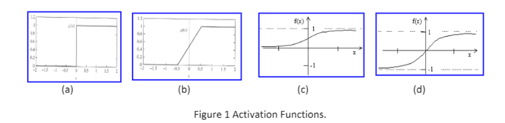

Question 2 please show the mathematical formulation of each activation function [0.5] and Explain the characteristics of each activation function [0.5 pt].

Piece wise Limiter

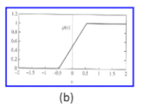

Formula

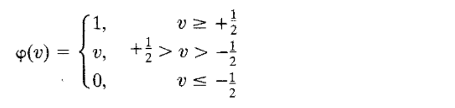

Explanation A linear combiner arises if the linear region of operation is maitained without running into saturation it says basically x axis is v and y axis is phi. basically says phi is 0 until x asxis is -5 and then phi is x axis value until .5+ then phi is 1

Hard Limiter

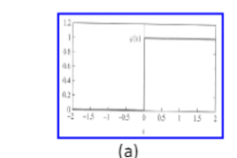

Formula Explanation: hardlimiter is a activiation function. hardlimiter functions calculate a layer's output from its net input. hardlimiter takes one input. It outputs 1 for positive values and for 0 values and less than 0 outputs 0

Hyperbolic function

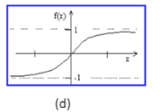

Sigmoid function

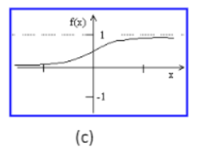

Formula: Explanation: Sigmoid is part of the activiation function family in machine learning. It helps to add non linearity in machine learning models.it also helps decide which value is best to pass as output and what not to allow as output.

Question 3[1 pt]Please show the perceptron structure and explain the function of each component [0.5 pt]. What is the purpose of using training examples in a neural network? Given properweight values, what is expected output vs. actual output of an example? [0.5 pt]

Question 3 [1 pt]Please show the perceptron structure and explain the function of each component [0.5 pt].

Neuron

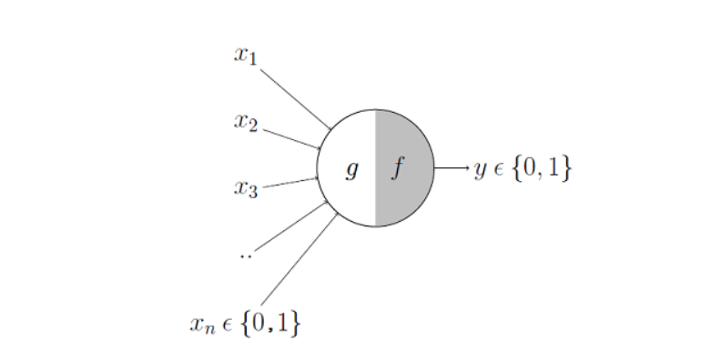

Neuron - is the portion that does the computation and reciveves input signals.It has two parts a summation Function and activation function. The summation Function just calculates the entire suim of all inputs that were sent in. Activation Function is a method that converts the incoming inputs and helps nueron learn the connections/relationships of the incoming and out going data. In screenshot is a example os a step function. There are many different type of activation functions these are some best known ones, step,sigmoid,softmax,Relu. above screenshot is step example.

Excitatory Input- this is the inputs to the nueron which can only be 1 or 0.

Inhibitory Input - this is the output of the nueron which also can take 1 or 0. 0 means wont trigger the nueron output and 1 means to trigger it.

Output - this is the output of the nueron which can be binary values. O means a triggering output and 1 means a non triggering output

Question 3 What is the purpose of using training examples in a neural network?

The purpose of using training examples in a nueral network solves a optimazation issue that finds the models weights which then results in a minimum error/loss when validatings results of the network

Question 3 Given properweight values, what is expected output vs. actual output of an example? [0.5 pt]

The range of input are sent in to nueron corresponding to expected output when a neural network is trained. Actual output is the result generated from a perceptron. When the actual result is different than the expected result then the weights applied to neurons are updated

Question 4[1pt]What is a Perceptron Learning Rule?[0.5 pt].What is the learning objective of the perceptron learning rule? [0.25 pt]

Question 4 What is a Perceptron Learning Rule?[0.5 pt]

A learning rule is used to train the network execute a certain task. There are many type os learning rules. There are only three categories each fall under supervised,unsupervised, and reinforcment.The Perceptron learning rule is a example of supervised training. Its when the learning rule is given a set of examples of correct outputs. Formula

{$ {input_{1}, t_{1}}$}, {$ {input_{2}, t_{2}}$}, ..., {$ {input_{Q}, t_{Q}}$}

$ input_{q} $ is a input to the network and $t_{q}$ is the expected output. When network goes through each input and applies it to the network the network output is compared to the target. The learning rule then adjusts the weights and biases of the whole nueral network in order to move the entire nueral network closer to the expected target.

Question 4 What is the learning objective of the perceptron learning rule? [0.25 pt]

The perceptron learning rule is a supervised learning rule which means you supply it with correct output and it will adjust the network in a way to get the network closer to the expected output. so the purposed of the perceptron learning rule is type of way to train a nueral network to adjust itsself to a given expected output and byitself.

Question 5[1 pt]What is a radient Descent Learning Rule?[0.25 pt]. What is the learning objective of the Gradient Descent Learning rule [0.25 pt].What arethe differences between perceptron learning rule vs. gradient descent learning rule?[0.5 pt]

Question 5 What is a Gradient Descent Learning Rule?

A Gradient Descent Learning Rule is a type of learning that helps train nueral networks. It is a learning rule that uses Gradient descent which is a optimization algorthm used to minimize some function by iteratively moving in the direction of steepest descent as defined by the negative of the gradient. The learning rule is used to update the weights of a nueral network based on the most optimised cost of a chosen cost function.

Question 5 What is the learning objective of the Gradient Descent Learning rule [0.25 pt]

Its purposes was to develop a learning algorithm to to reduce a cost function by making appropriate iterative adjustment to the weights in tthe network. So it applies iterative updates to weights until the cost is minimal as possible.

Question 5 What are the differences between perceptron learning rule vs. gradient descent learning rule?[0.5 pt]

The perceptron learning rules determines the direction that each weight needed to bring the output closer to the expected output. Gradient descent learning rules determines the direction the weight vectors needs to change based on how the best to reduce the given cost function. So best way to explain the difference Perceptron learning rule changes weights based on expected output and Gradient descent learning rule changes weights based on best on optimised cost reduction.

Question 6[1pt]What is stochastic gradient descent learning [0.5 pt]? What are the differences between gradient descent learning vs. stochastic gradient descent learning [0.5 pt]?

Question 6 What is stochastic gradient descent learning [0.5 pt]?

Stochastice gradiant descent learning is a nueral netowrk learning algorithm that is used to update the weights of a nueral network based on the most optimised cost of a chosen cost function but uses random samples from the training data in each run to update weights during optimization.

Question 6 What are the differences between gradient descent learning vs. stochastic gradient descent learning [0.5 pt]?

Stochastice gradiant descent learning and gradient descent learning are both similiar the difference appears when iterating ion gradient descent learning we consider all data points in training data in determinig optimised cost and in stochastic we use random data points in that determination.

Question 7 [1.5pts] Figure 2 shows two groups of instances (green vs. red) which belongs to class C1and C2, respectively. Assume a neuron with weight values [w0, w1, w2]is used to learn decision surface to separate the two groups instances (w0is the weight value for bias), •Draw decision surfaces corresponding to [1, 1, 1], [-1, 1,1], and [0, 1, -1], respectively [0.5 pt] (mark each line on the plot)[0.5 pt] •Explain how does each weight values [w0, w1, w2] control the decision surface, respectively [0.5 pt]•Among the three decision surfaces, which line is the best decision surface to separate instances, why? [0.tpt]

•Draw decision surfaces corresponding to [1, 1, 1], [-1, 1,1], and [0, 1, -1], respectively [0.5 pt] (mark each line on the plot)[0.5 pt]

•Explain how does each weight values [w0, w1, w2] control the decision surface, respectively [0.5 pt]•Among the three decision surfaces, which line is the best decision surface to separate instances, why? [0.tpt]

[1,1,1]

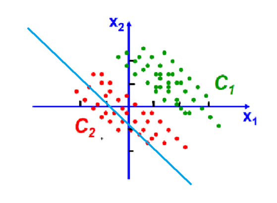

To many missclassified red dots hear not optimal

[-1,1,1]

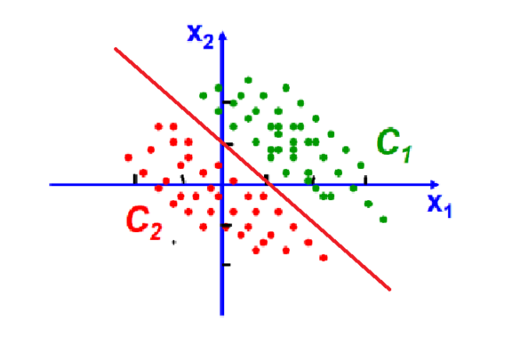

No misclassfication happen here when bounday line is drawed in this is the most optimal

[0,1,-1]

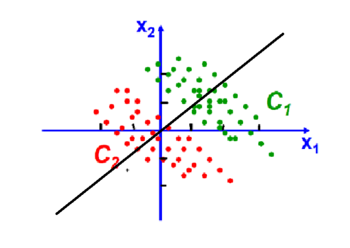

There is many misclassfications happening here on both dots

I used formula $ {w_0} + {w_1} x + {w_2} y = 0$ I chose [-1,1,1] as the best because there is no misclassifcations

Question 8[2pts]Assuming we have twosets of instances, which belong to two classes, with each class containing three instances. C1={(1, 0), (1, 1), (0, -1)}; C2={(0, 1), (-1, 0), (-1, -1)}. Assuming the class lable for C1 and C2 are 1 and 0, respectively, the learning rate=0.5, and the initial weights are w0=1, w1=1, and w2=1. Please use perceptron learning ruleto learn a linear decision surface for these two classes. List the results in the first two rounds by using tables in the following form.[show your calculations.]Assume the activation is defined as follow.

```python
import pandas as pd
import numpy as np
import matplotlib.pyplot as plt
import random
import seaborn as sns
from sklearn.model_selection import train_test_split
from IPython.display import display, HTML
np.warnings.filterwarnings('ignore', category=np.VisibleDeprecationWarning)

class perceptron_learning_rule_question_8:
    def __init__(self):
        req1 =  [-1, 1, 0, 0, -1, 1]
        req2 = [-1, 1, -1, 1, 0, 0]
        req3 = [0, 1, 1, 0, 0, 1]
        req_weights = [1, 1, 1]
        # column names come from assignment requirement table
        column_labels = ["Round", "Input", 'Weight', 'V  calc', 'Desired', 'Actual', 'New Weight']
        self.final_output_table_dataframe = pd.DataFrame(columns=column_labels)
        # for iterator
        self.iteration_counter = 1
        # from requirement doc
        self.set_of_features = pd.DataFrame({"A": req1, "B": req2, "C":req3})
        # come frome assignment reqs
        self.initial_weights = np.array(req_weights)
        # learning rate given from assignment
        self.learning_rate = .5
        # rounds
        self.iteration_round = 2
        #get values
        self.label_value = self.set_of_features.C.values
        #get values get
        self.feat_value = self.set_of_features[["A", "B"]].values
        self.learning_rule()

    def calculate_v(self, transposed_value):
        # The np.dot () function accepts three arguments and returns the dot product of two given vectors
        return np.dot(self.initial_weights, transposed_value)

    def calculate_actual(self, value):
        # pass in v to calculate actual
        if (value >= 0):
            return 1
        else:
            return 0

    def calculate_d(self, i, current_actual):
        return (self.label_value[i] - current_actual)

    def calculate_feature_resolver(self, current_value, current_round, i):
        # transpose the data
        self.transposed_value = current_value.transpose()
        # calculate v column
        self.v_column_calculated = self.calculate_v(self.transposed_value)

        # calculate actual column
        self.calculatlated_actual_column = self.calculate_actual(self.v_column_calculated)
        # calc value
        self.current_d_calc = self.calculate_d(i, self.calculatlated_actual_column)
        # set weights to temp
        self.temp_weight = self.initial_weights

        if (self.current_d_calc != 0):
            calc_for_iw = (self.current_d_calc * current_value * self.learning_rate)
            self.initial_weights = calc_for_iw + self.initial_weights

        self.build_new_row(current_value, current_round, i)

    def build_new_row(self, current_value, current_round, i):
        # create the new row
        round_ = current_round + 1
        input_ = current_value
        column_w = self.temp_weight
        v_column = self.v_column_calculated
        desired = self.label_value[i]
        act = self.calculatlated_actual_column
        init_weights = self.initial_weights
        self.row = [round_, input_, column_w, v_column, desired, act, init_weights]
        self.add_to_grid()

    def add_to_grid(self):
        # add  row to data frame
        self.final_output_table_dataframe.loc[len(self.final_output_table_dataframe)] = self.row
        # add to iter counter
        self.iteration_counter += 1

    def learning_rule(self):
        for current_round in range(self.iteration_round):
            for index, current_value in enumerate(self.feat_value):
                current_value = np.insert(current_value, 0, 1)
                # handles each row on table
                self.calculate_feature_resolver(current_value, current_round, index)
        display(self.final_output_table_dataframe)


perceptron_learning_rule_question_8()
```

|  | Round | Input | Weight | V calc | Desired | Actual | New Weight |
| --- | --- | --- | --- | --- | --- | --- | --- |
| 0 | 1 | [1, -1, -1] | [1, 1, 1] | -1 | 0 | 0 | [1, 1, 1] |
| 1 | 1 | [1, 1, 1] | [1, 1, 1] | 3 | 1 | 1 | [1, 1, 1] |
| 2 | 1 | [1, 0, -1] | [1, 1, 1] | 0 | 1 | 1 | [1, 1, 1] |
| 3 | 1 | [1, 0, 1] | [1, 1, 1] | 2 | 0 | 1 | [0.5, 1.0, 0.5] |
| 4 | 1 | [1, -1, 0] | [0.5, 1.0, 0.5] | -0.5 | 0 | 0 | [0.5, 1.0, 0.5] |
| 5 | 1 | [1, 1, 0] | [0.5, 1.0, 0.5] | 1.5 | 1 | 1 | [0.5, 1.0, 0.5] |
| 6 | 2 | [1, -1, -1] | [0.5, 1.0, 0.5] | -1.0 | 0 | 0 | [0.5, 1.0, 0.5] |
| 7 | 2 | [1, 1, 1] | [0.5, 1.0, 0.5] | 2.0 | 1 | 1 | [0.5, 1.0, 0.5] |
| 8 | 2 | [1, 0, -1] | [0.5, 1.0, 0.5] | 0.0 | 1 | 1 | [0.5, 1.0, 0.5] |
| 9 | 2 | [1, 0, 1] | [0.5, 1.0, 0.5] | 1.0 | 0 | 1 | [0.0, 1.0, 0.0] |
| 10 | 2 | [1, -1, 0] | [0.0, 1.0, 0.0] | -1.0 | 0 | 0 | [0.0, 1.0, 0.0] |
| 11 | 2 | [1, 1, 0] | [0.0, 1.0, 0.0] | 1.0 | 1 | 1 | [0.0, 1.0, 0.0] |

```
<__main__.perceptron_learning_rule_question_8 at 0x1b3b51df220>
```

notes for above:

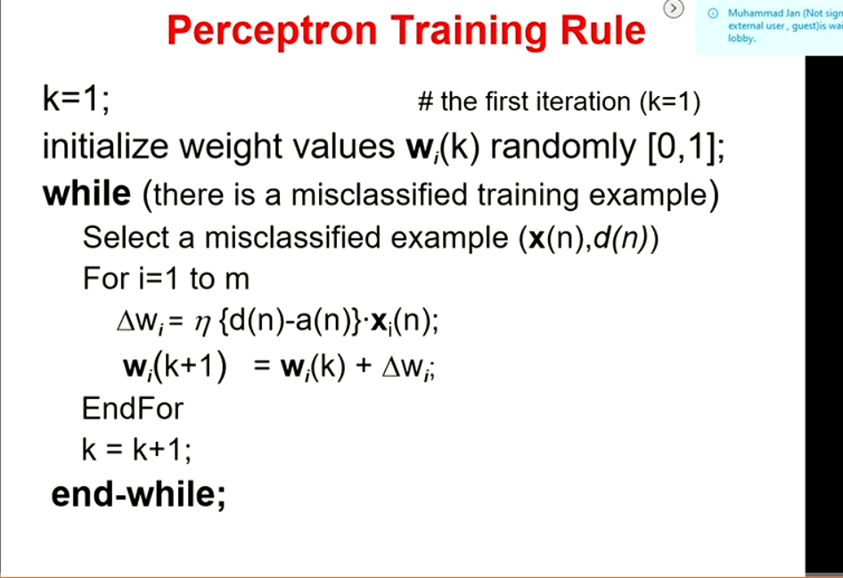

Question 9[2pts]Assuming we have two sets of instances, which belong to two classes, with each class containingthree instances. C1={(1, 0), (1, 1), (0, -1)}; C2={(0, 1), (-1, 0), (-1, -1)}. Assuming the class lable for C1 and C2 are 1 and 0, respectively, the learning rate =0.2, and the initial weights are w0=1, w1=1, and w2=1. Please use gradient descent learning ruleto learn a linear decision surface for these two classes. List the results in the first two rounds by using tables in the following form •Please also report the mean squared errors E(W) after the weight updating for each round.The First Round

```python
import matplotlib
import pandas as pd
import numpy as np
import matplotlib.pyplot as plt
import random
import seaborn as sns
from sklearn.model_selection import train_test_split
np.warnings.filterwarnings('ignore', category=np.VisibleDeprecationWarning)
from IPython.display import display

class gradient_descent_learning_rule_question_9:
    def __init__(self):
        #given from requirements hw
        req1 =  [-1, 1, 0, 0, -1, 1]
        req2 =  [-1, 1, -1, 1, 0, 0]
        req3 =  [0, 1, 1, 0, 0, 1]
        req_weights = [1, 1, 1]
        # columns can be found from hw and video
        self.column_labels = ["round", "niput", 'Weight', 'vcalc', 'Desired', 'W', 'W_i', 'W__x', "Error", "W(k+1)"]
        self.final_output_table_dataframe = pd.DataFrame(columns=self.column_labels)
        self.features = pd.DataFrame({"a": req1, "b": req2, "c": req3})
        self.features["c"] = req3
        self.set_feats = self.features[["a", "b"]].values
        self.label_value = self.features.c.values
        self.list_of_errors = []
        self.init_weights = np.array(req_weights)
        self.learning_rate = .2
        self.iteration_round = 2
        self.iteration_counter = 1
        gd = self.learning_rule_gradient_descent()
        display(gd)

    def row_handler(self,round_,i,x,tempWeight,theta_w_summed):
        x = np.insert(x, 0, 1)
        trans_ = x.transpose()
        v_column_calc = np.dot(self.init_weights, trans_)
        calculate_lab_with_v = (self.label_value[i] - v_column_calc)
        calced_out = self.learning_rate * calculate_lab_with_v
        self.list_of_errors.append(calculate_lab_with_v)
        theta_w = calced_out * x
        theta_w_summed += theta_w
        self.build_row_columns(round_,tempWeight,theta_w,theta_w_summed,calced_out,i,x,v_column_calc)
    def build_row_columns(self,round_, tempWeight,theta_w,theta_w_summed,calced_out,i,x,v_column_calc):
        self.weight_list = []
        for _weight_ in tempWeight:
            self.weight_list.append("%2.1f" % _weight_)
        self.d_list = []
        for _del in theta_w:
            self.d_list.append("%2.1f" % _del)
        self.del_list = []
        for _delta_ in theta_w_summed:
            self.del_list.append("%2.1f" % _delta_)
        self.round_iter = round_ + 1
        self.input_ = x
        self.weight = self.weight_list
        self.v_cal = v_column_calc
        self.desire_param = self.label_value[i]
        self.learning_d_n = calced_out
        self.d_weight = self.d_list
        self.d_w = np.array(self.del_list)
        self.row_to_add = [self.round_iter, self.input_,
                      self.weight,
                      self.v_cal,
                      self.desire_param,
                      self.learning_d_n,
                      self.d_weight,
                      self.d_w, '', '']
        self.add_to_grid()

    def add_to_grid(self):
        self.final_output_table_dataframe.loc[self.iteration_counter, self.column_labels] = self.row_to_add
        self.iteration_counter += 1

    def learning_rule_gradient_descent(self):
        for round_ in range(self.iteration_round):
            tempWeight = self.init_weights
            theta_w_summed = np.zeros(3)
            self.list_of_errors = []
            for count, value in enumerate( self.set_feats):
               self.row_handler(round_,count,value,tempWeight,theta_w_summed)
            self.init_weights = self.init_weights + theta_w_summed
            calc1 = (np.array(self.list_of_errors) ** 2.0).sum() / len( self.set_feats)
            list_init_we=[]
            for _w_ in self.init_weights:
                list_init_we.append("%2.3f" % _w_)
            final_col = [calc1,list_init_we]
            self.final_output_table_dataframe.loc[self.iteration_counter - 1, ["Error", "W(k+1)"]] = final_col
        display(self.final_output_table_dataframe)

gradient_descent_learning_rule_question_9()
```

|  | round | niput | Weight | vcalc | Desired | W | W_i | W__x | Error | W(k+1) |
| --- | --- | --- | --- | --- | --- | --- | --- | --- | --- | --- |
| 1 | 1 | [1, -1, -1] | [1.0, 1.0, 1.0] | -1 | 0 | 0.2 | [0.2, -0.2, -0.2] | [0.2, -0.2, -0.2] |  |  |
| 2 | 1 | [1, 1, 1] | [1.0, 1.0, 1.0] | 3 | 1 | -0.4 | [-0.4, -0.4, -0.4] | [-0.2, -0.6, -0.6] |  |  |
| 3 | 1 | [1, 0, -1] | [1.0, 1.0, 1.0] | 0 | 1 | 0.2 | [0.2, 0.0, -0.2] | [0.0, -0.6, -0.8] |  |  |
| 4 | 1 | [1, 0, 1] | [1.0, 1.0, 1.0] | 2 | 0 | -0.4 | [-0.4, -0.0, -0.4] | [-0.4, -0.6, -1.2] |  |  |
| 5 | 1 | [1, -1, 0] | [1.0, 1.0, 1.0] | 0 | 0 | 0.0 | [0.0, -0.0, 0.0] | [-0.4, -0.6, -1.2] |  |  |
| 6 | 1 | [1, 1, 0] | [1.0, 1.0, 1.0] | 2 | 1 | -0.2 | [-0.2, -0.2, -0.0] | [-0.6, -0.8, -1.2] | 1.833333 | [0.400, 0.200, -0.200] |
| 7 | 2 | [1, -1, -1] | [0.4, 0.2, -0.2] | 0.4 | 0 | -0.08 | [-0.1, 0.1, 0.1] | [-0.1, 0.1, 0.1] |  |  |
| 8 | 2 | [1, 1, 1] | [0.4, 0.2, -0.2] | 0.4 | 1 | 0.12 | [0.1, 0.1, 0.1] | [0.0, 0.2, 0.2] |  |  |
| 9 | 2 | [1, 0, -1] | [0.4, 0.2, -0.2] | 0.6 | 1 | 0.08 | [0.1, 0.0, -0.1] | [0.1, 0.2, 0.1] |  |  |
| 10 | 2 | [1, 0, 1] | [0.4, 0.2, -0.2] | 0.2 | 0 | -0.04 | [-0.0, -0.0, -0.0] | [0.1, 0.2, 0.1] |  |  |
| 11 | 2 | [1, -1, 0] | [0.4, 0.2, -0.2] | 0.2 | 0 | -0.04 | [-0.0, 0.0, -0.0] | [0.0, 0.2, 0.1] |  |  |
| 12 | 2 | [1, 1, 0] | [0.4, 0.2, -0.2] | 0.6 | 1 | 0.08 | [0.1, 0.1, 0.0] | [0.1, 0.3, 0.1] | 0.153333 | [0.520, 0.520, -0.120] |

```
None
```

```
<__main__.gradient_descent_learning_rule_question_9 at 0x1a085734040>
```

Question 10[2pts]Assuming we have two sets of instances, which belong to two classes, with each class containingthree instances. C1={(1, 0), (1, 1), (0, -1)}; C2={(0, 1), (-1, 0), (-1, -1)}. Assuming the class lable for C1 and C2 are 1 and 0, respectively, the learning rate =0.2, and the initial weights are w0=1, w1=1, and w2=1. Please use Deltalearning rule(AdaLine)to learn a linear decision surface for these two classes. [show your calculations.]•List the results in the first round by using tablein the following form•Please also report the mean squared errors E(W) after the weight updating for the firstround.

```python
import matplotlib
import pandas as pd
import numpy as np
import matplotlib.pyplot as plt
import random
import seaborn as sns
from sklearn.model_selection import train_test_split

pd.set_option('display.max_rows', 500)
pd.set_option('display.max_columns', 500)
pd.set_option('display.width', 1000)
from IPython.display import display

import warnings

warnings.filterwarnings("ignore", category=DeprecationWarning)


# todo port to flask
class gradient_descent_learning_rule_question_10_service:
    def __init__(self):

        self.column_labels = ["round", "Input", 'Weight', 'd_esired', 'V', 'output', 'deltaW', 'New Weight', "Error"]
        self.final_output_table_dataframe = pd.DataFrame(columns=self.column_labels)
        self.req1 = [-1, 1, 0, 0, -1, 1]
        self.req2 = [-1, 1, -1, 1, 0, 0]
        self.req3 = [0, 1, 1, 0, 0, 1]
        self.features = pd.DataFrame({
            "a": self.req1,
            "b": self.req2,
            "c": self.req3})
        self.features["c"] = self.req3
        self.set_feats = self.features[["a", "b"]].values
        self.lab_values = self.features.c.values
        self.error_value = 0
        self.init_weights = np.array([1, 1, 1])
        self.learning_rate = .2
        self.iteration_round = 1
        self.iteration_counter = 0
        gd = self.learning_rule_delta_handler()
        display(gd)

    def calculate_v(self, transposed_value):
        return np.dot(self.init_weights, transposed_value)

    def calculate_d(self, i, current_value, x):
        return self.learning_rate * (self.lab_values[i] - current_value) * x

    def learning_rate_delata_column_handler(self, calculated_d):
        lr_list = []
        for x in calculated_d:
            lr_list.append("%2.1f" % x)
        return lr_list

    def new_w_column_handler(self):
        new_weight_list = []
        for x in self.init_weights:
            new_weight_list.append("%.2f" % x)
        return new_weight_list

    def weight_column_calc(self, weight):
        new_weight_list = []
        for x in weight:
            new_weight_list.append("%2.1f" % x)
        return new_weight_list

    def row_handler(self, round_, x, i):
        transposed_value = x.transpose()
        self.v_calc = self.calculate_v(transposed_value)
        calculated_d = self.calculate_d(i, self.v_calc, x)
        self.cal_for_form = (self.lab_values[i] - self.v_calc) ** 2
        self.error_value = self.error_value + self.cal_for_form
        weight = self.init_weights
        self.init_weights = self.init_weights + calculated_d
        self.roundcolumn_val = round_ + 1
        weight_column_calc = np.array(self.weight_column_calc(weight))
        self.lr_calc = self.learning_rate_delata_column_handler(calculated_d)
        self.new_weight_column = self.new_w_column_handler()
        self.iteration_counter += 1
        self.build_row(x, i, weight_column_calc)

    def build_row(self, x, i, weight_column_calc):
        row = [self.roundcolumn_val,
               x,
               weight_column_calc,
               self.lab_values[i],
               self.v_calc,
               self.v_calc,
               self.lr_calc,
               self.new_weight_column,
               '']
        self.final_output_table_dataframe.loc[self.iteration_counter, self.column_labels] = row
        length_check = len(self.set_feats)
        current_validation = self.iteration_counter % length_check
        if current_validation == 0:
            calculate_E = self.error_value / len(self.set_feats)
            self.final_output_table_dataframe.loc[len(self.final_output_table_dataframe), "Error"] = calculate_E

    def learning_rule_delta_handler(self):
        for round in range(self.iteration_round):
            for count, value in enumerate(self.set_feats):
                value = np.insert(value, 0, 1)
                self.row_handler(round, value, count)
        return self.final_output_table_dataframe


gradient_descent_learning_rule_question_10_service()
```

|  | round | Input | Weight | d_esired | V | output | deltaW | New Weight | Error |
| --- | --- | --- | --- | --- | --- | --- | --- | --- | --- |
| 1 | 1 | [1, -1, -1] | [1.0, 1.0, 1.0] | 0 | -1 | -1 | [0.2, -0.2, -0.2] | [1.20, 0.80, 0.80] |  |
| 2 | 1 | [1, 1, 1] | [1.2, 0.8, 0.8] | 1 | 2.8 | 2.8 | [-0.4, -0.4, -0.4] | [0.84, 0.44, 0.44] |  |
| 3 | 1 | [1, 0, -1] | [0.8, 0.4, 0.4] | 1 | 0.4 | 0.4 | [0.1, 0.0, -0.1] | [0.96, 0.44, 0.32] |  |
| 4 | 1 | [1, 0, 1] | [1.0, 0.4, 0.3] | 0 | 1.28 | 1.28 | [-0.3, -0.0, -0.3] | [0.70, 0.44, 0.06] |  |
| 5 | 1 | [1, -1, 0] | [0.7, 0.4, 0.1] | 0 | 0.264 | 0.264 | [-0.1, 0.1, -0.0] | [0.65, 0.49, 0.06] |  |
| 6 | 1 | [1, 1, 0] | [0.7, 0.5, 0.1] | 1 | 1.144 | 1.144 | [-0.0, -0.0, -0.0] | [0.62, 0.46, 0.06] | 1.054805 |

```
<__main__.gradient_descent_learning_rule_question_10_service at 0x1a08576e970>
```

Question 11[3pts] Class1.txtand Class2.txtfiles in the Canvas contain two-dimensional instances in two classes (C1and C2respectively, with 100 instances in each class).

In these two files, the first column denotes the xvalues and the second column represents the yvalues (separated by comma).

Please use skeleton code in Gradient Descent Learning[Notebook, pdf ] in Canvas to implement following tasks•Combine instances in the Class1.txtand Class2.txtfiles as one dataframe, and label instances in Class1 as 2, and instances in Class2 as -2. [0.25 pt]

•Report the scatter plot of all 200 instances in the same plot, using “Blue” color to show instances in Class1 and uses “Green” to show instances in Class 2[0.25 pt]

•Randomly select 80% instances from class1.txt and 80% instances from class2.txt to train a perceptron classifier(using gradient descent learning rule), and use the classifier to classify remaining 20% instances in class1.txt and class2.txt. Report the classification accuracyof the perceptron classifier on the 20% test instances (using learning rate=1/(# of training samples), error threshold 0.1, and iteration numbers 2000) [0.5pt]

•Report training errors and test errors of the perceptron classifier with respect to each iteration. Show the two error rates on the same chart, where the x-axis denotes the iteration and the y-axis denotes the mean classification errors [0.5pt] •Report the final decision surface on the same scatter plot which shows the 200 instances [0.5pt]

•Pleaseuse Delta rule function in the Gradient Descent Learning [Notebook, pdf] to learn from the same 80% of training samples (using learning rate =0.01, error threshold 0.1, and iteration numbers 2000). oReport the training errors as a plot, where the x-axis denotes the iteration and the y-axis denotes the mean classification errors [0.5 pt]oCompare Delta learing rule and Gradient Descent Learning rule, explain the advantage and disadvantage of each of them, respectively [0.5 pt]

Randomly select 80% instances from class1.txt and 80% instances from class2.txt to train a perceptron classifier(using gradient descent learning rule), and use the classifier to classify remaining 20% instances in class1.txt and class2.txt. Report the classification accuracyof the perceptron classifier on the 20% test instances (using learning rate=1/(# of training samples), error threshold 0.1, and iteration numbers 2000) [0.5pt]

```
[1, 2, 3, 4, 6, 8, 9, 10, 11, 12, 13, 14, 16, 17, 18, 19, 20, 21, 22, 23, 24, 25, 26, 27, 28, 29, 30, 31, 32, 33, 34, 35, 36, 37, 38, 39, 40, 41, 42, 43, 44, 45, 46, 47, 48, 49, 50, 51, 52, 53, 54, 55, 56, 57, 58, 59, 60, 61, 62, 63, 64, 65, 66, 67, 68, 69, 70, 71, 72, 73, 75, 76, 77, 79, 80, 81, 82…
```

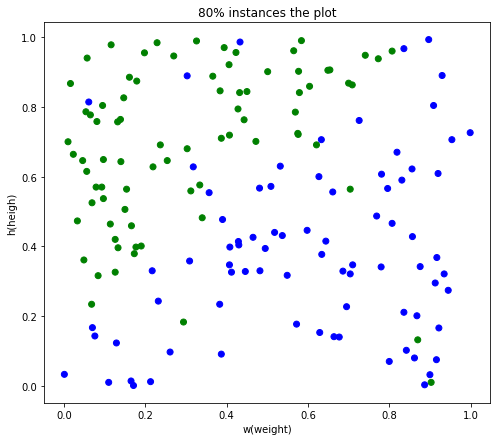

```python
import matplotlib
import pandas as pd
import numpy as np
import matplotlib.pyplot as plt
import random
import seaborn as sns
from sklearn.model_selection import train_test_split
from sklearn.utils import shuffle

class questions_11_data_analysis:
    def __init__(self):
        self.colors = ["blue", "green", 'green']
        self.load_data_for_init()

    def load_data_for_init(self):
        #load data analyze print out and train
        self.class1 = pd.read_csv("class1.txt")
        self.class2 = pd.read_csv("class2.txt")
        self.class_df_1 = self.class1.append(self.class2)
        self.class1.insert(self.class1.shape[1], 'label', 1)
        self.class_1_sample_df = self.class1.sample(frac=.8)
        self.class2.insert(self.class2.shape[1], 'label', -1)
        self.class_2_sample_df =self. class2.sample(frac=.8)
        self.class_df3 = self.class_1_sample_df.append(self.class_2_sample_df, sort=False)
        self.class_1_2_df_random = shuffle(self.class_df3)
        self.feats, labs = self.class_1_2_df_random.iloc[:, 0:-1], self.class_1_2_df_random.loc[:, ['label']]
        self.a_train, self.a_test, self.b_train, self.b_test = train_test_split(self.feats, labs, test_size=.2, random_state=45)
        self.a_train_m = np.asmatrix(self.a_train, dtype='float64')
        self.a_test_m = np.asmatrix(self.a_test, dtype='float64')
        self.b_train_m = np.asmatrix(self.b_train, dtype='float64')
        self.b_test_m = np.asmatrix(self.b_test, dtype='float64')
        self.features = self.a_train_m
        self.labels = self.b_train_m
        self.Gd_calculated_learning_rate = 1.0/self.a_train.shape[0]
        self.test_features = self.a_test_m
        self.test_labels = self.b_test_m
        current_index = 0
        self.data_example_ = []
        for i, row in self.class_df3.iterrows():
            current_index = current_index + 1
            r_weight= row['weight']
            r_height = row['height']
            r_label = row['label']
            calc_validator_ = ((r_weight - r_height ) * (-r_label))
            if (calc_validator_ >= 0.1):
                self.data_example_.append(current_index)
        print(self.data_example_)
    def handle_colors(self):
        self.color_gen = []
        for current_index in  self.class_df3.iloc[:, 2]:
            self.color_gen.append(self.colors[current_index + 1])
    def plot_data_80_requirement(self):
            plt.figure()
            plt.figure(figsize=(8, 7))
            x = self.class_df3.iloc[:, 0]
            y = self.class_df3.iloc[:, 1]
            self.handle_colors()
            plt.scatter(x, y, color=self.color_gen)
            plt.xlabel('w(weight)')
            plt.ylabel('h(heigh)')
            plt.title('80% instances the plot')
            plt.show()

q11_req_1 = questions_11_data_analysis()
q11_req_1.plot_data_80_requirement()
```

•Report training errors and test errors of the perceptron classifier with respect to each iteration. Show the two error rates on the same chart, where the x-axis denotes the iteration and the y-axis denotes the mean classification errors [0.5pt]

```
learning_rate0.0078125
[1.880407643361543, 1.6230284782980235, 1.5077564333183893, 1.4395417624571336, 1.3903675768049824, 1.351378617936196, 1.319295020184133, 1.2925405326525783, 1.2701258530561401, 1.2513154933620487, 1.235519280263074, 1.2222497636133973, 1.2111002093695278, 1.2017300304615692, 1.193853672093972]
[0.5709498636769176, 0.35578587334446354, 0.4055681894910537, 0.34671821187383084, 0.356030529616635, 0.33478691885664696, 0.33287425653644254, 0.32317536059931284, 0.3194819006669113, 0.31417919779823533, 0.3110149528936541, 0.3077910479318534, 0.3054867484107264, 0.3034330375138504, 0.301857565796…
[0.375, 0.71875, 0.75, 0.875, 0.84375, 0.90625, 0.875, 0.90625, 0.90625, 0.9375]
```

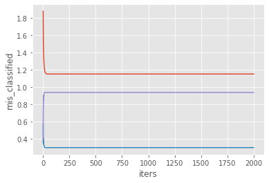

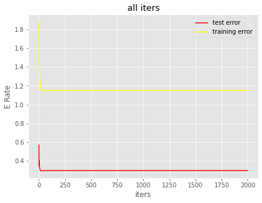

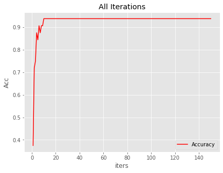

```python
import matplotlib
import pandas as pd
import numpy as np
import matplotlib.pyplot as plt
import random
import seaborn as sns
from sklearn.model_selection import train_test_split
from sklearn.utils import shuffle


class gradient_descent_learning_rule_question_11:
    def __init__(self, total_iterations, error_threshold_param):
        self.features = ''
        self.labels = ''
        self.Gd_calculated_learning_rate = ''
        self.test_features = ''
        self.test_labels = ''
        self.max_iterations = total_iterations
        self.err_threshold = error_threshold_param
        self.load_data_for_init()
        self.learning_rate = self.Gd_calculated_learning_rate
        self.Squared_Errors = []
        self.Squared_errors_validation = []
        self.current_ep = 0
        self.acc = []
        self.error_value = 9999.0
        self.current_error = 0
        self.randomWeight_calc = 0
        self.GradientDescentLearningHandler()
        self.color_gen = []
        self.colors = ["blue", "green", 'green']

    def init_weight(self):
        return np.random.rand(self.features.shape[1] + 1) - 0.5

    def enum_features(self, random_weight):
        for i, x in enumerate(self.features):
            x = np.insert(x, 0, 1)
            v = np.dot(random_weight, x.transpose())
            self.current_error = self.current_error + (self.labels[i] - v) * (self.labels[i] - v)
        self.current_error = np.ndarray.item(self.current_error)
        self.current_error = self.current_error / 2.0
        self.error_value = self.current_error / self.features.shape[0]
        self.Squared_Errors.append(self.current_error / self.test_features.shape[0])

    def enum_test(self, random_weight):
        for i, x in enumerate(self.test_features):
            x = np.insert(x, 0, 1)
            v = np.dot(random_weight, x.transpose())
            self.current_error = self.current_error + (self.test_labels[i] - v) * (self.test_labels[i] - v)
        self.current_error = np.ndarray.item(self.current_error)
        self.current_error = self.current_error / 2.0
        self.Squared_errors_validation.append(self.current_error / self.test_features.shape[0])

    def enum_test_with_label_validation(self, random_weight):
        for i, x in enumerate(self.test_features):
            x = np.insert(x, 0, 1)
            v = np.dot(random_weight, x.transpose())
            if ((v >= 0 and self.test_labels[i] < 0) or (v < 0 and self.test_labels[i] >= 0)):
                self.current_error = self.current_error + 1

    def GradientDescentLearningHandler(self):
        random_weight = self.init_weight()
        while (self.current_ep < self.max_iterations) and (self.error_value > self.err_threshold):
            misclassified = 0
            deltaw = [0] * (self.features.shape[1] + 1)
            for i, x in enumerate(self.features):
                x = np.insert(x, 0, 1)
                v = np.dot(random_weight, x.transpose())
                diff = self.learning_rate * (self.labels[i] - v)
                deltaw = deltaw + diff * x
            random_weight = random_weight + deltaw
            self.current_error = 0
            self.enum_features(random_weight)
            self.current_error = 0
            self.enum_test(random_weight)
            self.current_error = 0
            self.enum_test_with_label_validation(random_weight)
            self.current_error = float(self.current_error)
            self.current_error = self.current_error / self.test_features.shape[0]
            self.acc.append(1 - self.current_error)
            self.current_ep = self.current_ep + 1
            self.randomWeight_calc = random_weight;

    def load_data_for_init(self):
        # load data and train and set feats caluclate learning rate
        self.class1 = pd.read_csv("class1.txt")
        self.class2 = pd.read_csv("class2.txt")
        self.class_df_1 = self.class1.append(self.class2)
        self.class1.insert(self.class1.shape[1], 'label', 1)
        self.class_1_sample_df = self.class1.sample(frac=.8)
        self.class2.insert(self.class2.shape[1], 'label', -1)
        self.class_2_sample_df = self.class2.sample(frac=.8)
        self.class_df3 = self.class_1_sample_df.append(self.class_2_sample_df, sort=False)
        self.class_1_2_df_random = shuffle(self.class_df3)
        self.feats, labs = self.class_1_2_df_random.iloc[:, 0:-1], self.class_1_2_df_random.loc[:, ['label']]
        self.a_train, self.a_test, self.b_train, self.b_test = train_test_split(self.feats, labs, test_size=.2,
                                                                                random_state=45)
        self.a_train_m = np.asmatrix(self.a_train, dtype='float64')
        self.a_test_m = np.asmatrix(self.a_test, dtype='float64')
        self.b_train_m = np.asmatrix(self.b_train, dtype='float64')
        self.b_test_m = np.asmatrix(self.b_test, dtype='float64')
        self.features = self.a_train_m
        self.labels = self.b_train_m
        self.Gd_calculated_learning_rate = 1.0 / self.a_train.shape[0]
        self.test_features = self.a_test_m
        self.test_labels = self.b_test_m

    def gd_plotter_handler(self):
        rounds = np.arange(1, self.max_iterations + 1)
        plt.plot(rounds, self.Squared_Errors)
        plt.plot(rounds, self.Squared_errors_validation)
        plt.plot(rounds, self.acc)
        plt.xlabel('iters')
        plt.ylabel('mis_classified')
        plt.show()

    def handle_colors(self):
        self.color_gen = []
        for current_index in self.class_df3.iloc[:, 2]:
            self.color_gen.append(self.colors[current_index + 1])

    def scatter_plot_200_instances_requirement(self):
        self.handle_colors()
        print('Slope = ', (self.randomWeight_calc[0, 1] / self.randomWeight_calc[0, 2] * (-1)))
        print('Intercept = ', (self.randomWeight_calc[0, 0] / self.randomWeight_calc[0, 2] * (-1)))
        x_axis = self.class_df3.iloc[:, 0]
        y_axis = x_axis * (self.randomWeight_calc[0, 1] / self.randomWeight_calc[0, 2] * (-1)) + (
                    self.randomWeight_calc[0, 0] / self.randomWeight_calc[0, 2] * (-1))
        x = self.class_df3.iloc[:, 0]
        y = self.class_df3.iloc[:, 1]
        plt.scatter(x, y, color=self.color_gen)
        plt.plot(x_axis, y_axis, "g-")
    def plot_test_errors_and_squared_errors_all(self):
        rounds = np.arange(1, self.max_iterations+1)
        plt.figure(figsize=(15, 5))
        plt.subplot(1,2,1)
        plt.plot(rounds,self.Squared_errors_validation, color= 'red',  label = 'test error')
        plt.plot(rounds,self.Squared_Errors, color = 'yellow', label = "training error")
        plt.xlabel('iters')
        plt.ylabel('E Rate')
        plt.title("all iters")
        plt.legend()
    def plot_acc_all(self):
        rounds = np.arange(1, gradient_object.max_iterations+1)
        plt.figure(figsize=(15, 5))
        plt.subplot(1,2,1)
        plt.plot(epochs[:150],gradient_object.acc[:150], color = 'r', label = "Accuracy")
        plt.xlabel('iters')
        plt.ylabel('Acc')
        plt.title("All Iterations")
        plt.legend()
gradient_object = gradient_descent_learning_rule_question_11(2000, 0.1)
print("learning_rate" + str(gradient_object.Gd_calculated_learning_rate))
print(gradient_object.Squared_Errors[0:15])
print(gradient_object.Squared_errors_validation[0:15])
print(gradient_object.acc[0:10])
gradient_object.gd_plotter_handler()
gradient_object.plot_test_errors_and_squared_errors_all()
gradient_object.plot_acc_all()
```

•Report the final decision surface on the same scatter plot which shows the 200 instances [0.5pt]

```
Slope =  1.1270485793026017
Intercept =  0.050039289678523315
```

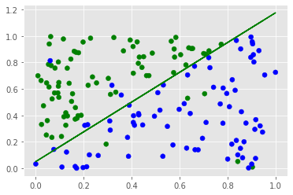

```python
gradient_object.scatter_plot_200_instances_requirement()
```

•Pleaseuse Delta rule function in the Gradient Descent Learning [Notebook, pdf] to learn from the same 80% of training samples (using learning rate =0.01, error threshold 0.1, and iteration numbers 2000). oReport the training errors as a plot, where the x-axis denotes the iteration and the y-axis denotes the mean classification errors [0.5 pt]oCompare Delta learing rule and Gradient Descent Learning rule, explain the advantage and disadvantage of each of them, respectively [0.5 pt]

```python
import random
import matplotlib
import pandas as pd
import numpy as np
import matplotlib.pyplot as plt
import random
import seaborn as sns
from sklearn.model_selection import train_test_split
import matplotlib.pyplot as plt
import pandas as pd
import numpy as np
from sklearn.utils import shuffle
from sklearn.model_selection import train_test_split
from IPython.display import display

#todo port to falsk on free time
import warnings
warnings.filterwarnings("ignore", category=DeprecationWarning)
class delta_method_requirements:
    def __init__(self,  total_iterations, current_learning_rate, error_threshold_param):
        self.current_features = ''
        self.current_labels = ''
        self.load_data_for_init()
        self.max_iterations = total_iterations
        self.current_learning_rate = current_learning_rate
        self.error_threshold_param = error_threshold_param
        self.Squared_Errors = []
        self.Squared_errors_validation = []
        self.round = 0
        self.differeenttial = 0
        self.current_d = 0
        self.error_max = 9999.0
        self.random_weight_init = np.random.rand(self.current_features.shape[1] + 1) - 0.5
        self.delta_handler()
        self.current_error_val = 0
        self.delta_handler()

    def errorHandling(self):
        self.current_error_val = np.asscalar(self.current_error_val)
        self.current_error_val = self.current_error_val / 2.0
        self.Squared_Errors.append(self.current_error_val)
        self.error_max = self.current_error_val / self.current_features.shape[0]
        self.round = self.round + 1

    def enum_currentFeats(self):
        self.random_weight_init = self.random_weight_init + self.current_d
        self.current_error_val = 0
        for i, x in enumerate(self.current_features):
            x = np.insert(x, 0, 1)
            v = np.dot(self.random_weight_init, x.transpose())
            self.current_error_val = self.current_error_val + (self.current_labels[i] - v) * (self.current_labels[i] - v)

    def v_handler(self, x):
        return np.dot( self.random_weight_init, x.transpose())

    def differential_handler(self, index, v_column_calc):
        return self.current_learning_rate * (self.current_labels[index] - v_column_calc)

    def delta_handler(self):
        while (self.round < self.max_iterations) and (self.error_max > self.error_threshold_param):
            self.current_d = [0] * (self.current_features.shape[1] + 1)
            i = random.randrange(self.current_features.shape[0])
            feat = self.current_features[i,]
            feat = np.insert(feat, 0, 1)
            v = self.v_handler(feat)
            self.differeenttial = self.differential_handler(i, v)
            self.current_d = self.current_d + self.differeenttial * feat
            self.enum_currentFeats()
            self.errorHandling()

    def load_data_for_init(self):
        #load data and train and set feats
        self.class1 = pd.read_csv("class1.txt")
        self.class2 = pd.read_csv("class2.txt")
        self.class_df_1 = self.class1.append(self.class2)
        self.class1.insert(self.class1.shape[1], 'label', 1)
        self.class_1_sample_df = self.class1.sample(frac=.8)
        self.class2.insert(self.class2.shape[1], 'label', -1)
        self.class_2_sample_df =self. class2.sample(frac=.8)
        self.class_df3 = self.class_1_sample_df.append(self.class_2_sample_df, sort=False)
        self.class_1_2_df_random = shuffle(self.class_df3)
        self.feats, labs = self.class_1_2_df_random.iloc[:, 0:-1], self.class_1_2_df_random.loc[:, ['label']]
        self.a_train, self.a_test, self.b_train, self.b_test = train_test_split(self.feats, labs, test_size=.2, random_state=45)
        self.a_train_m = np.asmatrix(self.a_train, dtype='float64')
        self.a_test_m = np.asmatrix(self.a_test, dtype='float64')
        self.b_train_m = np.asmatrix(self.b_train, dtype='float64')
        self.b_test_m = np.asmatrix(self.b_test, dtype='float64')
        self.current_features = self.a_train_m
        self.current_labels = self.b_train_m

    def delta_method_plot_handler(self):
        rounds = np.arange(1, self.max_iterations+1)
        plt.plot(rounds, self.Squared_Errors, color='blue')
        plt.xlabel('iters')
        plt.ylabel('misclassfications')
        plt.show()

delta = delta_method_requirements(2000, 0.01, 0.1)
display(delta.Squared_Errors[0:15])
```

```
[56.74235604070786,
 56.52978815093173,
 56.290803364720325,
 56.345339572363535,
 56.47057298200291,
 56.60314408886398,
 56.306722618612056,
 56.13269093866411,
 56.19461524187129,
 55.953114183977725,
 56.00755217023767,
 56.12950919627178,
 56.22935591263694,
 56.39443744720583,
 56.14180802761696]
```

[figure not shown]

```python
delta.delta_method_plot_handler()
```

Compare Delta learing rule and Gradient Descent Learning rule, explain the advantage and disadvantage of each of them, respectively¶

The difference between delta looks for what is the best weight that would make the nueal network fit training set best with minimum and error and also helps with performance and does this a each instnace in instance.Delta learning rule will try to find the best values for the weights by comparing actual output with target output to find a match with the minumum error. gradient descent learning we consider all data points in training data in determining optimised cost. It looks for the best optimised cost function.

Question 12 [1.5pts] Please download review100.csvdataset from Canvas, and use a programming language (Python, R, etc.)to implement tasks below. The review100.csv includes 100 movie reviews (from IMDB) and the sentiment (positive vs. negative) of the reviewer (there are 50 positive reviews and 50 negative reviews)

. Each review (each row) contains two parts. The first column is the reviews (text), and the second column is the sentiment (positive or negative).

•Read reviews from the review100.csv. Tokenize each review using space key, so each review is represented as a set of tokens (words) . Use the top 1,000 most frequent tokens (words) as features to represent each review (so each review is represented as an instance with 1000 features). The value of each feature is 1 if the view has the corresponding token/word, or 0 otherwise. Use .head() to show the first several rows of the data frame. [0.5 pt]

•Use 1 as the label of the positive review, and 0 as the label of the negative review (so each review is represented using1,000 features and a class label). Use .head() to show the first several rows of the data frame. [0.5 pt]

•Calculate conditional entropy and information gain of each token/word, and report the top-50 tokens/words with the highest information gain values (as a bar plot, where x-axis shows the word and y-axis shows the information gain values) [0.5 pt]

```python
import matplotlib
import pandas as pd
import numpy as np
import matplotlib.pyplot as plt
import random
import seaborn as sns
from sklearn.model_selection import train_test_split
import re
from sklearn.feature_extraction.text import CountVectorizer
from math import log2

class question_12_review100:
    def __init__(self):
        self.count_vectorizer = CountVectorizer()
        self.imported_review = pd.read_csv("review100.csv")
        self.print_sentiment_review_movie_remove_dead()
        self.vectorize_data()
        self.parsee_feat_names_from_vectorizedd()
        self.create_df_for_most_common_Req()
        self.create_1000_freq_token()
        self.last_val = lambda x:  x[0] if len(x) != 0 else x
        self.information_gain_execution()

    def regex_down_row(self,current_r):
        #make regex faster throw it to lowercase and throw all patterns on list and add as you find them
        current_r = current_r.lower()
        parse_list = [r"<br />", r'(\n+)|(\s+)',r"[.,(){}]", r"[<>\\/]",r"\"",r" +"]
        #loop through found paterns in data
        for i in parse_list:
            current_r = re.sub(i, ' ', current_r)
        # strip for sanity chek
        current_r = current_r.strip()
        return current_r

    def print_sentiment_review_movie_remove_dead(self):
        self.imported_review['movie review'] = self.imported_review['movie review'].apply(self.regex_down_row)

    def vectorize_data(self):
        values_to_transform = self.imported_review["movie review"].values
        self.vectorized = self.count_vectorizer.fit_transform(values_to_transform)

    def parsee_feat_names_from_vectorizedd(self):
        self.feature_names = self.count_vectorizer.get_feature_names()

    def create_df_for_most_common_Req(self):
        send_vectorized_to_list = self.vectorized.toarray()
        self.df_word_breakdown = pd.DataFrame(send_vectorized_to_list, columns=self.feature_names)
        self.most_frequent_work_req = self.df_word_breakdown.sum().sort_values(ascending=False)[:1000]

    def create_1000_freq_token(self):
        get_freq_word_with_req_from_hw = np.where(self.df_word_breakdown[self.most_frequent_work_req.index] > 0, 1, 0)
        get_index_from_most_freq = self.most_frequent_work_req.index
        self.features_1000_d_f = pd.DataFrame(get_freq_word_with_req_from_hw, columns=get_index_from_most_freq)
        self.features_1000_d_f["sentiment"] = self.imported_review["sentiment"]

    def entropy_handler(self, current_data_frame, i_col):
        current_calc_e = 0
        for i in current_data_frame[i_col].unique():
            len_current_df = len(current_data_frame)
            current_index_from_df = current_data_frame[i_col].value_counts()[i]
            a_calc = -(current_index_from_df / len_current_df)
            b_calc = log2(current_index_from_df / len_current_df)
            current_calc_e += a_calc * b_calc
        return current_calc_e

    def entrop_logic(self, i_col, sentiment_column):
        current = 0
        unique_from_df = self.features_1000_d_f[i_col].unique()
        total_calc_e = {}
        for i in unique_from_df:
            conditional_calculated = (self.features_1000_d_f[i_col].value_counts()[i] / len(self.features_1000_d_f))
            current_entropy_handler_calculated = self.entropy_handler(self.features_1000_d_f[self.features_1000_d_f[i_col] == i], sentiment_column)
            current += conditional_calculated * current_entropy_handler_calculated
            total_calc_e[i] = [current_entropy_handler_calculated]
        current_return = [current, total_calc_e]
        return current_return

    def ig_handler(self, i_column, sentiment_column):
        e_calced = self.entropy_handler(self.features_1000_d_f, sentiment_column)
        get_calc = self.entrop_logic(i_column, sentiment_column)
        first_ = self.last_val(get_calc)
        codition_e_calc = first_
        info_gain = e_calced - codition_e_calc
        row = [info_gain, codition_e_calc]
        return row

    def information_gain_execution(self):
        list_of_values = []
        curent_df = self.features_1000_d_f.columns[:-1]
        for i_column in curent_df:
            #runn it through information gain handler
            list_of_values.append(self.ig_handler(i_column, 'sentiment'))
        get_index_from_1000_df = self.features_1000_d_f.columns[:-1]
        self.information_gain = pd.DataFrame(list_of_values, columns=['infor_gain', "conditional_entropy"], index=get_index_from_1000_df)
        self.information_gain_top_50 = self.information_gain.sort_values(by="infor_gain", ascending=False)[:50]
        self.clean_sort_for_final = self.information_gain.sort_values(by="infor_gain", ascending=False)[:50]

    def plot_information_gaiin(self):
        plt.figure(figsize=(45, 15))
        plt.barh(self.information_gain_top_50.index, self.information_gain_top_50["infor_gain"], color='blue', label="Freq_ Word_")
        plt.style.use('ggplot')
        plt.xticks(rotation=90)
        plt.xlabel("word lis")
        plt.ylabel("innfo Gain")
        plt.title("top50 info gain")
        plt.show()


q12_object = question_12_review100()
```

```python
q12_object.imported_review.head()
```

|  | movie review | sentiment |
| --- | --- | --- |
| 0 | one of the other reviewers has mentioned that ... | positive |
| 1 | a wonderful little production the filming tech... | positive |
| 2 | i thought this was a wonderful way to spend ti... | positive |
| 3 | basically there's a family where a little boy ... | negative |
| 4 | petter mattei's love in the time of money is a... | positive |

```python
q12_object.feature_names[:100]
```

```
['00',
 '000',
 '10',
 '100',
 '103',
 '11',
 '12',
 '13',
 '15',
 '17',
 '1794',
 '1800',
 '1930s',
 '1936',
 '1937',
 '1940',
 '1947',
 '1956',
 '1963',
 '1981',
 '1990',
 '1990s',
 '1992',
 '1997',
 '20',
 '2002',
 '2003',
 '227th',
 '23',
 '25',
 '26',
 '29',
 '30',
 '300',
 '33',
 '360',
 '36th',
 '47',
 '50',
 '51',
```

[output cut: 45 more lines]

```
 'accuses',
 'accustomed',
 'achieve',
 'achieved',
 'achievement',
 'achingly',
 'acquired',
 'across',
 'acroyd',
 'act',
 'acted',
 'acting',
 'action',
 'actions',
 'activate']
```

. Use the top 1,000 most frequent tokens (words) as features to represent each review (so each review is represented as an instance with 1000 features). The value of each feature is 1 if the view has the corresponding token/word, or 0 otherwise. Use .head() to show the first several rows of the data frame. [0.5 pt]

```python
q12_object.features_1000_d_f.head()
```

|  | the | and | of | to | is | in | it | this | that | was | with | as | for | movie | but | film | his | on | he | not | at | you | by | are | all | one | be | have | who | … |
| --- | --- | --- | --- | --- | --- | --- | --- | --- | --- | --- | --- | --- | --- | --- | --- | --- | --- | --- | --- | --- | --- | --- | --- | --- | --- | --- | --- | --- | --- | --- |
| 0 | 1 | 1 | 1 | 1 | 1 | 1 | 1 | 1 | 1 | 1 | 1 | 1 | 1 | 0 | 1 | 0 | 0 | 1 | 0 | 1 | 0 | 1 | 0 | 1 | 1 | 1 | 1 | 1 | 1 | … |
| 1 | 1 | 1 | 1 | 1 | 1 | 0 | 1 | 0 | 0 | 0 | 1 | 0 | 0 | 0 | 1 | 0 | 1 | 1 | 1 | 1 | 0 | 1 | 1 | 1 | 1 | 1 | 0 | 0 | 0 | … |
| 2 | 1 | 1 | 1 | 1 | 1 | 1 | 1 | 1 | 1 | 1 | 1 | 0 | 0 | 0 | 1 | 0 | 1 | 1 | 0 | 1 | 1 | 0 | 0 | 1 | 0 | 1 | 1 | 1 | 0 | … |
| 3 | 1 | 1 | 1 | 1 | 1 | 1 | 0 | 1 | 0 | 0 | 1 | 1 | 1 | 1 | 0 | 1 | 1 | 0 | 0 | 0 | 0 | 1 | 0 | 1 | 1 | 0 | 0 | 1 | 0 | … |
| 4 | 1 | 1 | 1 | 1 | 1 | 1 | 0 | 1 | 1 | 0 | 1 | 1 | 1 | 1 | 1 | 1 | 1 | 1 | 0 | 1 | 0 | 0 | 0 | 1 | 1 | 1 | 1 | 0 | 0 | … |

5 rows × 1001 columns

```python
q12_object.most_frequent_work_req.head()
```

```
the    1461
and     690
of      623
to      560
is      448
dtype: int64
```

```python
q12_object.clean_sort_for_final
```

|  | infor_gain | conditional_entropy |
| --- | --- | --- |
| upon | 0.096431 | 0.903569 |
| man | 0.095796 | 0.904204 |
| may | 0.089198 | 0.910802 |
| funny | 0.085024 | 0.914976 |
| world | 0.078557 | 0.921443 |
| mother | 0.078557 | 0.921443 |
| love | 0.075709 | 0.924291 |
| wonderful | 0.073804 | 0.926196 |
| unique | 0.073804 | 0.926196 |
| stupid | 0.073804 | 0.926196 |
| could | 0.069342 | 0.930658 |
| makes | 0.068232 | 0.931768 |
| young | 0.065573 | 0.934427 |
| times | 0.065573 | 0.934427 |
| awful | 0.062764 | 0.937236 |
| horrible | 0.062764 | 0.937236 |
| police | 0.062764 | 0.937236 |
| was | 0.059888 | 0.940112 |
| takes | 0.058237 | 0.941763 |
| has | 0.058215 | 0.941785 |
| worst | 0.056208 | 0.943792 |
| romance | 0.051899 | 0.948101 |
| days | 0.051899 | 0.948101 |
| surprise | 0.051899 | 0.948101 |
| waste | 0.051899 | 0.948101 |
| bored | 0.051899 | 0.948101 |
| michael | 0.051899 | 0.948101 |
| tells | 0.051899 | 0.948101 |
| cinema | 0.051899 | 0.948101 |
| school | 0.051899 | 0.948101 |
| major | 0.051899 | 0.948101 |
| wife | 0.051899 | 0.948101 |
| gives | 0.051899 | 0.948101 |
| human | 0.051899 | 0.948101 |
| him | 0.050922 | 0.949078 |
| without | 0.048595 | 0.951405 |
| bad | 0.043296 | 0.956704 |
| give | 0.043242 | 0.956758 |
| his | 0.043119 | 0.956881 |
| just | 0.042242 | 0.957758 |
| unless | 0.041203 | 0.958797 |
| century | 0.041203 | 0.958797 |
| straight | 0.041203 | 0.958797 |
| music | 0.041203 | 0.958797 |
| fantastic | 0.041203 | 0.958797 |
| public | 0.041203 | 0.958797 |
| whom | 0.041203 | 0.958797 |
| pick | 0.041203 | 0.958797 |
| white | 0.041203 | 0.958797 |
| journey | 0.041203 | 0.958797 |

[figure not shown]

```python
q12_object.plot_information_gaiin()
```

```python
# run this to view all object properties for q12
attrs = vars(q12_object)
print(', '.join("%s: %s" % item for item in attrs.items()))
```

[output not shown]